# Arbuscular mycorrhizal fungi colonization package

### 0.0.11 Plot data

To summarise the data in a graphical way the package provide 3 plot types:

- barplot

> am_barplot
- boxplot

> am_boxplot
- dotplot

> am_dotplot

It is possible to plot a simple plot.

#### 0.0.11.1 Example

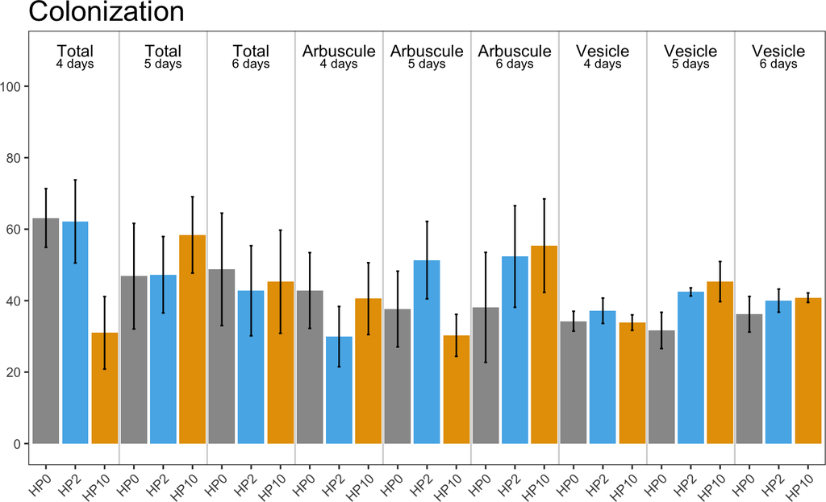

```r
am_barplot(tgr)
```

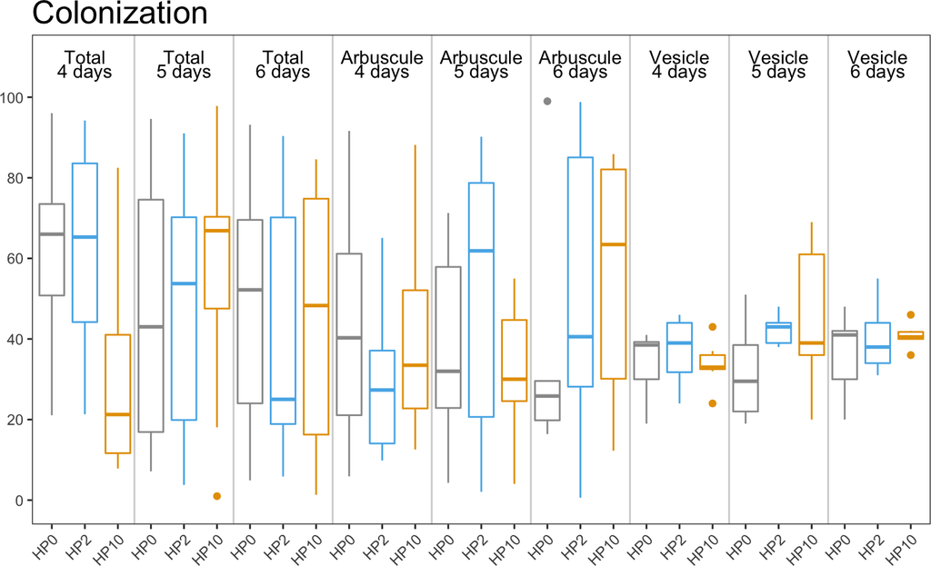

```r
am_boxplot(tgr)
```

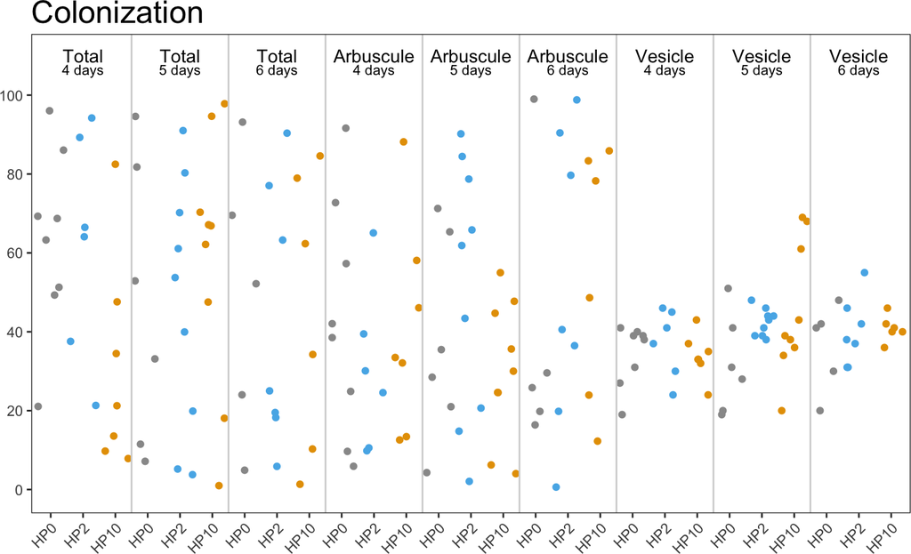

```r
am_dotplot(tgr)
```

The plot fuctions for time points take the same set of option to customize your plot as the previous plots.

It is also possible to include the statistical results under the plot with the appropriate alpha. In time point data analysis the “asterisks” option does not work. The “letter” option works across the same feature for all the time points. So, you can compare the “Total” for different samples, but you can not compare different features at different time points (eg, the comparison between “Total” HP0 after 4 days and “Arbuscule” HP0 after 4 days is meaningless).

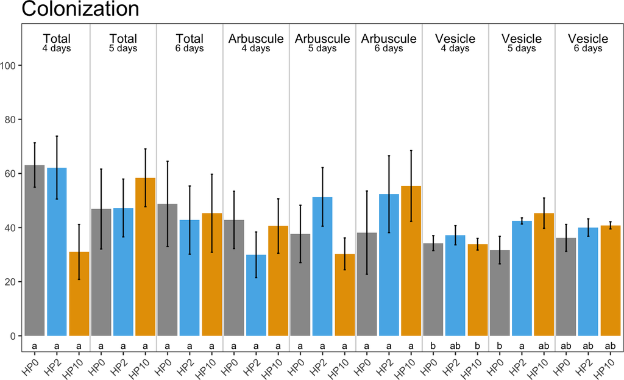

```r
am_barplot(tgr, annot = "letter", alpha = 0.05)
```

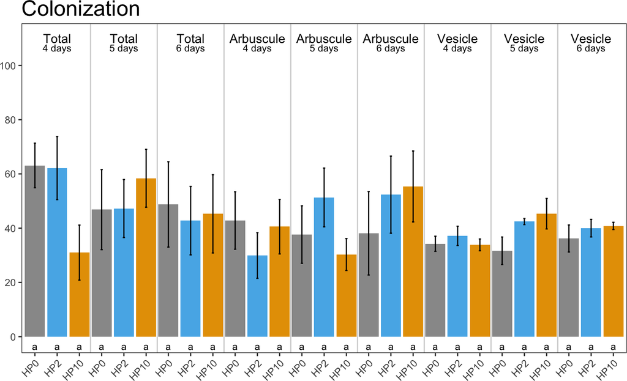

```r
am_barplot(tgr, annot = "letter", alpha = 0.01)
```

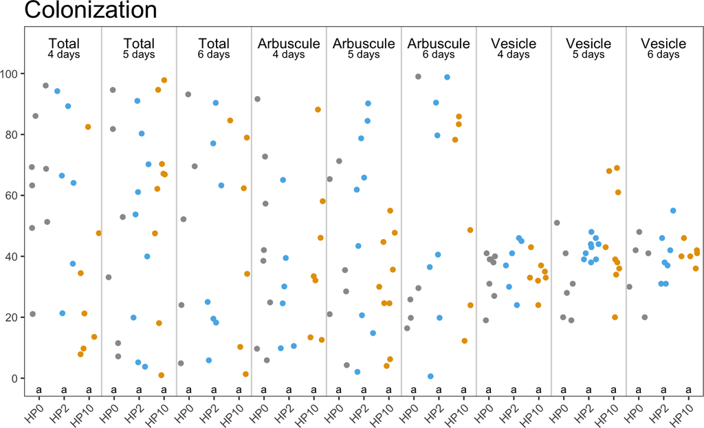

```r
am_dotplot(tgr, annot = "letter", method = "fdr")
```

### 0.0.12 Save data

To export the data, a “save data” function is provided.

- **Summary data**: the function exports both the summary per replicate and the summary per sample in two distinct csv files.
- **Statistical data**: the function exports a csv file
- **Plots**: the function exports the plots and useful options can be used to export a pubblication ready image.

#### 0.0.12.1 Example

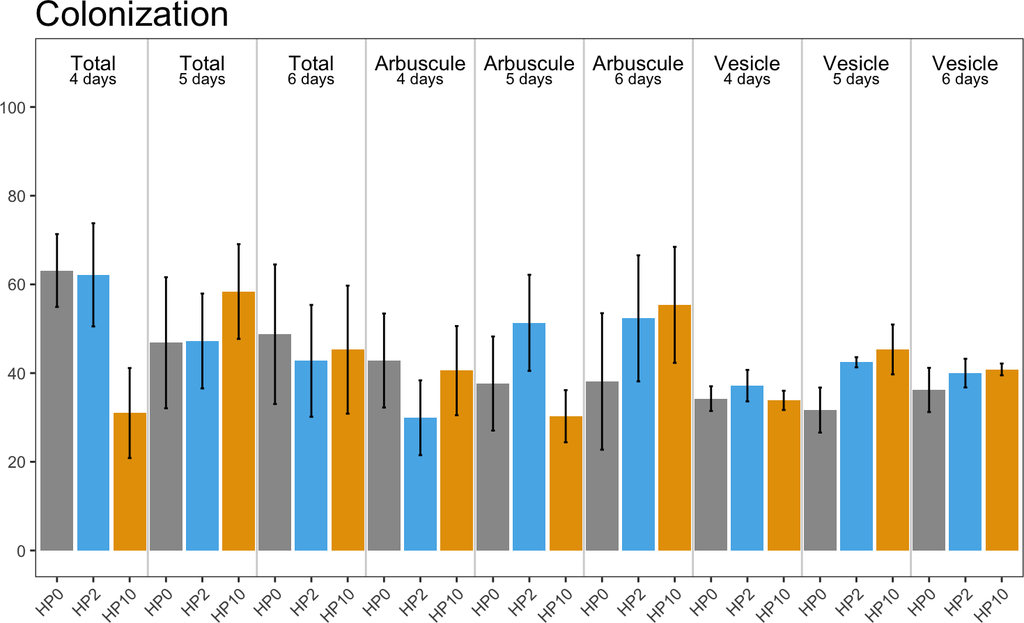

```r
# Save the summary
am_save(tgrs, "TimePoint") # Two files will be saved

# Save the statisticas
am_save(am_stat(tgr, method = "BH"), "TimePoint") # One file called Summary_Stat.csv will be saved

# Save the plots
am_save(am_barplot(tgr), "barplor_Timegrid.pdf")
# Save jpg plot
tgrb <- am_barplot(tgr)
```

```r
am_save(tgrb, "RPlot.pdf", unit = "cm", width = 20, height = 20, dpi = 300)
```